```r
library(tidyverse)
library(gridExtra)
library(grid)
library(knitr)
library(lubridate)
library(scales)
library(ggrepel)
library(kableExtra)
library(zoo)
AccentCol01 <- "firebrick"
knitr::opts_chunk$set(fig.width=10, dpi=300)
```

This data is downloaded directly from the [European CDC](https://www.ecdc.europa.eu/en/publications-data/download-todays-data-geographic-distribution-covid-19-cases-worldwide). This data requires formating the dates and calculating the cumulative totals. If you want to the data already ‘cleaned/wrangled’, you can take it from [Our World in Data](https://ourworldindata.org/coronavirus) who gets their data from the Eurpoean CDC. They file can be found [here](https://ourworldindata.org/coronavirus-source-data) and is called `full_data.csv`; also called “All four metrics”.

This data is from the ECDC and thus updated based on Eurpoean time zone days. Because of this the datas and values do not match up with the [American CDC](https://www.cdc.gov/coronavirus/2019-ncov/cases-updates/cases-in-us.html) values. However, I am sticking with the EDC data set as it is available for download; where the CDC data is not.

```r
#download data directly from European CDC
raw_data <- read.csv("https://opendata.ecdc.europa.eu/covid19/casedistribution/csv"
                     , na.strings = "", fileEncoding = "UTF-8-BOM")


covid19_US <- raw_data %>%
  #only look at USA
  filter(countryterritoryCode  == "USA") %>%
  #read date character into date format
  mutate(date = as.Date(dateRep, format="%d/%m/%Y")) %>%
  #order by date
  arrange(date) %>%
  #calculate cumulative sums
  mutate(
      total_cases = cumsum(cases)
    , total_deaths = cumsum(deaths)
  ) %>%
  #only select date, new cases, new deaths
  select(
      date
    , new_cases = cases
    , new_deaths =deaths
    , total_cases
    , total_deaths
    )
```

One important calculation is the growth rate. The growth rate is calculated as follows:

$$\text{Growth Rate} = \frac{ \text{New-Cases}_N}{\text{New-Cases}_{N-1}}$$
where $N$ is a given day. If the growth rate is below 1 that means the number of new cases is slowing down - this is a positive sign.

I also wanted to look at the dealth percentage which I calculated as the total number of dealths divided by the total number of cases for a given day.

```r
#number of rows; use for `for loop`
R <- nrow(covid19_US)

#GROWTH FACTOR
covid19_US$growth_factor <- NA

#calculate growth rate
#start with 2 because when r=1; 1-1= 0 (don't have a 0th row)
for (r in 2:R){
  covid19_US$growth_factor[r] <-
    #Growth Factor = New Cases Today / New Cases Yesterday
    covid19_US$new_cases[r] /  covid19_US$new_cases[r-1]
}


#DEATH PERCENTAGE
covid19_US$death_percentage <- NA

# calculate dealth percentage
for (r in 1:R){
  covid19_US$death_percentage[r] <-
    #dealth percentage = total deaths / total cases
    covid19_US$total_deaths[r] /  covid19_US$total_cases[r]
}

#calculate moving average
ma_k <- 5
covid19_US$MA_growth_factor <- c(rep(NA, ma_k - 1), rollmean(covid19_US$growth_factor, k=5))
covid19_US$MA_new_cases <- c(rep(NA, ma_k - 1), rollmean(covid19_US$new_cases, k=5))


#save copy of data
write.csv(covid19_US, "data_ECDC.csv")
```

```r
startdate <- "2020-03-17"
#3/18 - start 'lockdown' ; after large growth factors↕


covid19_US_adj <- covid19_US  %>%
  #only look at data after a given start date
  filter(date >= as.Date(startdate)) %>%
  #remove any NA's that are still present
  drop_na()
```

```r
#find current values to use as labels

current_date <- max(covid19_US_adj$date)

current_values <- covid19_US_adj %>%
    #return row that has current date
    filter(date == current_date)


current_US_deaths      <- current_values$total_deaths
current_US_totalcases  <- current_values$total_cases
current_US_newcases <- current_values$new_cases
current_US_growthfact  <- current_values$growth_factor
current_US_deathperc   <- current_values$death_percentage
current_US_newdeaths <- current_values$new_deaths
```

```r
#set the limits for the x-axis
#want the limits to be the same so the axes for different charts line up
#need to add extra for the bar charts

x_min <- as.Date(startdate)-.5
x_max <- as.Date(current_date)+1

#ggplot set ups
date_scaling <- scale_x_date(
      name = NULL
    , labels = date_format("%b-%d")
    , limits = c(x_min, x_max)
    , expand = c(0, 0)
  )

thousands_scaling <- scale_y_continuous(
      name = NULL
    , limits = c(0, NA)
    , labels = scales::unit_format(unit = "k", scale = 1e-3, accuracy = 1, big.mark = ",")
  )

title_size <- 16
subtitle_size <- 12
```

### Total Cases and Total Deaths

These show the cumulative total of cases and deaths.

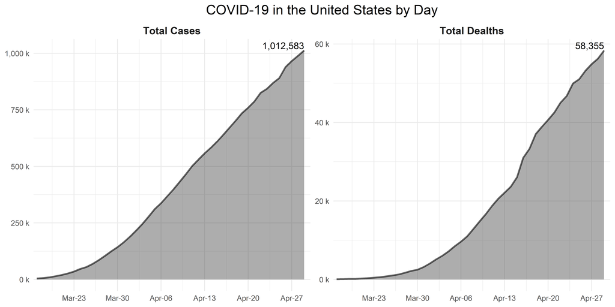

```r
covid_tidy <- covid19_US_adj %>%
  select(date, total_cases, total_deaths) %>%
  pivot_longer(
      cols = c(total_cases, total_deaths)
    , names_to = "type"
    , values_to = "count"
  )

covid_labels <- covid_tidy %>%
  filter(date == current_date)



ggplot(covid_tidy, aes(date, count)) +
  geom_area(alpha = 0.4)+
  geom_line(
      size = 1
    , alpha = 0.6
  )+
  facet_wrap(
    .~factor(type, labels = c("Total Cases", "Total Dealths"))
    , ncol=2
    , scales = "free_y"
  ) +
  date_scaling +
  thousands_scaling +
  geom_text(
      data = covid_labels
    #format label so there is a comma after three places
    , aes(label = formatC(count, big.mark=",", format="d"))
    , vjust = -0.2
    , hjust=1
    ) +
  theme_minimal() +
  ggtitle("COVID-19 in the United States by Day") +
  theme(
      plot.title = element_text(size = title_size, hjust = 0.5)
  #  , axis.text.x = element_text(hjust = 0.2)
    , strip.text.x = element_text(size = subtitle_size, face = "bold")
  )
```

### Growth Factor and New Cases

In order to see if the pandemic is slowing down, it is helpful to look at the growth factor and the daily new cases. For both these values; we want to see a decrease in values from day to day - which indicates that less people are getting sick. Recall that a growth factor less than 1 is a positive sign that the growth of cases is slowing down. Growth factor is directly related to new cases - if daily new cases goes now the growth factor is less than 1; if daily cases goes up the growth factor is greater than one. These two charts represent the same information in two differnt ways.

```r
#captions
gf_max <- max(covid19_US_adj$growth_factor)

cap_gf <- "A growth factor above 1 means new cases are increasing,\ni.e. the pandemic is growing"
```

```r
#plot set up
plot_gf_setup  <- ggplot(covid19_US_adj, aes(x=date, y=growth_factor))+
  annotate(
      "rect"
    , xmin = x_min
    , xmax = x_max
    , ymin =  1
    , ymax =  Inf
    , fill = AccentCol01
    , alpha = 0.2
    ) +
  annotate(
      "segment"
    , x     = x_min
    , xend  = x_max
    , y     =  1
    , yend  =  1
    , color = AccentCol01
    , linetype = "dotted"
    , size = 1
    ) +
  annotate(
      "text"
    , x = x_min + 1
    , y = gf_max
    , label = cap_gf
    , vjust="inward"
    , hjust= 0
  )+
  date_scaling +
  ylim(0, NA)+
  ggtitle("Growth Factor") +
  theme_minimal()+
  theme(
      plot.title = element_text(hjust = 0.5, size = subtitle_size, face = "bold")
    #, axis.text.x = element_text(hjust = 0.2)
    , axis.title.x=element_blank()
    , axis.title.y=element_blank()
  )
```

```r
#daily cases set up

plot_dc_setup <- ggplot(covid19_US_adj, aes(x=date, y=new_cases))+
  date_scaling +
  thousands_scaling +
  ggtitle("New Cases") +
  theme_minimal()+
  theme(
      plot.title = element_text(hjust = 0.5, size = subtitle_size, face = "bold")
    , axis.title.x=element_blank()
    , axis.title.y=element_blank()
  )
```

There can be a lot of variability in the daily points - this is due to many different variables. On variable is the availability of tests, cases will go down if there is scarcity of tests and rise dramatically when more tests become available. One way to help get a better sense over the overall trend is by smoothing the data.

```r
plot_gf_smooth  <- plot_gf_setup +
  #geom_line(aes(y = MA_growth_factor), size=1.1, alpha=0.6)+
    geom_point(
      size=2
    , alpha=0.3
  )+
  geom_line(
      size=1
    , alpha=0.3
  ) +
  geom_smooth(
      size = 2
    , color="grey35"
    , se = FALSE
    , alpha = 0.6
    , method = "loess"
    , formula = y~x
    , span = 0.9
  )
```

```r
#new cases by date bar chart

plot_dc_smooth <- plot_dc_setup +
  #geom_line(aes(y = MA_new_cases), alpha=0.6, size= 1.1)+
  geom_col(alpha=0.3)+
  geom_smooth(
    size = 2
    , color="grey35"
    , alpha = 0.6
    , se = FALSE
    , method = "loess"
    , formula = y ~x
    , span = 0.9
  )
#  stat_smooth(
#      method = "lm"
#    , formula = y ~ x + I(x^2)
#  )
```

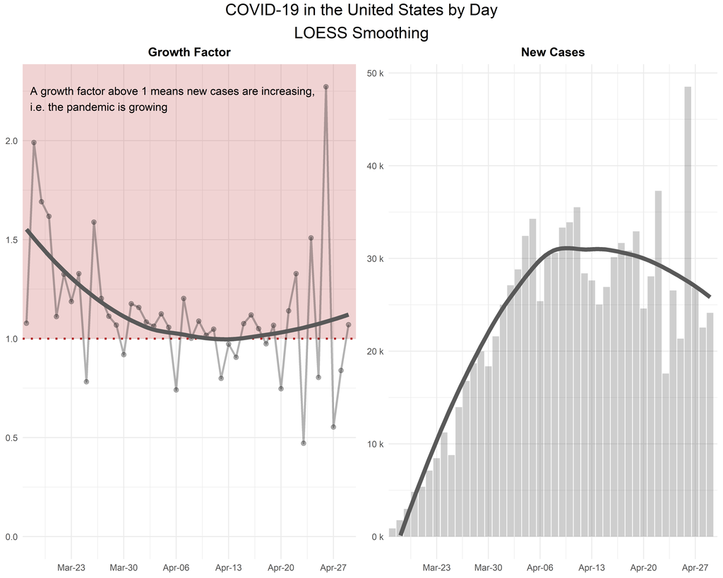

```r
#Put the plots together and have the plot axes line up

grid.arrange(
    plot_gf_smooth
  , plot_dc_smooth
  , nrow = 1
  ,top=textGrob(
      "COVID-19 in the United States by Day\nLOESS Smoothing"
    , gp=gpar(fontsize=title_size)
  )
)
```

### New Deaths and Death Percentage

```r
#start by defining two fucntion

#round number to specific base
func_mround <- function(x, base){
  base*round(x/base)
}

#round up to a certain base; this will be used for upper bound for primary axis
Ylim <- function(curr_val, base){
round_curr_val <- func_mround(curr_val, base)
if( round_curr_val - curr_val < 0 ){
  lim <- round_curr_val + base
} else {
  lim <- round_curr_val
}
return(lim)
}
```

```r
#td = total deaths
#set base for primary axis
dd_base <- 1000

#primary/main y-axis limit
dd_y1lim  <- Ylim(max(covid19_US_adj$new_deaths), dd_base)
  #add an extra base to add more room


#TRANSFORM PRIMARY AXIS TO SECONDARY AXIS
#in order to have a secondary axis have to have a multiplier to transform primary axis to sec axis
#find the Ylim of primary axis
# next want to find an upper bound for seconday axis
#     want both upper bounds to be divisible by the same number
#     i.e. if the primary axis is from 0 to 20 and it has 4 breaks (5, 10, 15, 20)
#     I want to set the upper bound of the secondary axis to a value divisible by 4
#     want teh break lines of the primary axis to match up with the breaks of the secondary axis
#what if I don't do this?
#     the text breaks of the seconday axis will not line up with the line breaks of the primary axis

#find what the divisor is
divisor <- dd_y1lim/dd_base

#max value for the secondary axis
maxdeathperc <- max(covid19_US_adj$death_percentage, na.rm=TRUE)


dp_y2lim  <- Ylim(maxdeathperc, .01)+.01

dp_base <- dp_y2lim/divisor

#calculate the breaks
dd_y1breaks <- c(1:divisor)*dd_base
dp_y2breaks <- c(1:divisor)*dp_base

#calculate the transform multiplier
dd_transform <- dd_y1lim*(1/dp_y2lim)
```

```r
#plot the primary data: new deaths by day bar chart

plot_dd <- ggplot(covid19_US_adj, aes(x=date))+
  #use geom_col because counts per day have alread been counted
  geom_col(aes(y=new_deaths), alpha=0.6)+
  #add total dealths label
  geom_label(
      data = current_values
    #format label so there is a comma after three places
    , aes(
        label = formatC(new_deaths, big.mark=",", format="d")
      , y     = new_deaths
      )
    , hjust = 0.75
    , nudge_y = 250
    )
```

```r
#Then, plot the secondary data: death percentage.

plot_dd <- plot_dd +
  geom_line(
    data = covid19_US_adj,
    #transformatio to match secondary axis below
      aes(y=death_percentage*dd_transform)
    , color=AccentCol01
    , size= 1
    )+
  geom_point(
    data = covid19_US_adj,
    #transformatio to match secondary axis below
      aes(y=death_percentage*dd_transform)
    #color
    , color=AccentCol01
    , size= 2
    )+
  #add label to most recent value
  geom_label(
      data = current_values
    , aes(
        label = percent(death_percentage, accuracy=0.001)
      # remember to add the transform!
      , y     = death_percentage*dd_transform
      )
    , hjust = 0.75
    , vjust = 0
    , nudge_y = .0020 * dd_transform
    , color = AccentCol01
    )
```

```r
#It is imparative to add the scales.

plot_dd <- plot_dd +
  #scale the date to be onece a week
  #add specific limits so it will line up with geom_line
  date_scaling +
  #add commas to numbers in y axis; requires scales package
  scale_y_continuous(
      limits = c(0, dd_y1lim)
    , breaks = dd_y1breaks
    #add commas to numbers in y axis; requires scales package
    , labels = scales::unit_format(unit = "k", scale = 1e-3, accuracy = 1, big.mark = ",")
    #this transformation MUST match the transformation above
    #divide by current_US_deaths leads to an axis of 0 to 1
    #divide by current_US_deaths*10 leads to an axis of 0 to 0.1
    , sec.axis = sec_axis(
        ~./dd_transform
      ,  breaks = dp_y2breaks
      )
    )
```

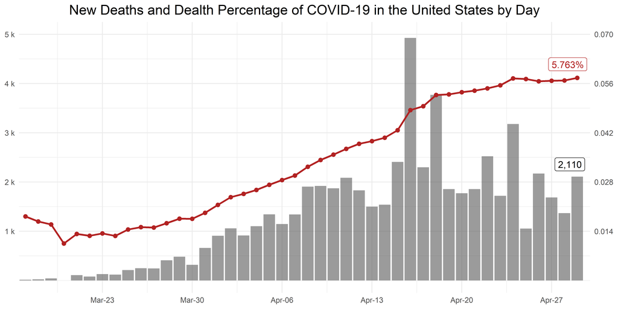

```r
#Finally, a title and other themes are specified.

plot_dd <- plot_dd +
  #add title
  ggtitle("New Deaths and Dealth Percentage of COVID-19 in the United States by Day")+
  #minimal theme
  theme_minimal()+
  theme(
    #remove all legents
     legend.position = "none"
     # remove x and y axes
    , axis.title.x = element_blank()
    , axis.title.y = element_blank()
    #adjust plot title
    , plot.title = element_text(hjust = 0.5, size = title_size)
  )

plot_dd
```

### Values for Past Week

```r
#transpose table; easier to read
covid19_US_adj %>%
  arrange(desc(date)) %>%
  top_n(7, wt=date) %>%
  #format data for output tabe
  mutate(
      Date = format(date, '%a, %b %d, %Y')
    , `Total Cases` = formatC(total_cases, big.mark=",", format="d")
    , `New Cases`  = formatC(new_cases, big.mark=",", format="d")
    , `Growth Factor` = round(growth_factor, 4)
    , `Total Deaths` = formatC(total_deaths, big.mark=",", format="d")
    , `New Deaths` = formatC(new_deaths, big.mark=",", format="d")
    , `Death Percentage` = percent(death_percentage, accuracy=0.001)
  ) %>%
  #re-order to group cases and death information together
  select(
      Date
    , `Total Cases`
    , `New Cases`
    , `Growth Factor`
    , `Total Deaths`
    , `New Deaths`
    , `Death Percentage`
    ) %>%
  kable(align=c('l', rep('r', 5))) %>%
  kable_styling(
    bootstrap_options = c(
      #adds stiped color to rows
        "striped"
      #highlight row when hover over it
      , "hover"
      #table doesn't have to be full width
      , full_width = FALSE
      #make it horizontally scrollable
      , "responsive"
      )
    ) %>%
  row_spec(1, bold=T, color="white", background = "rgba(0, 0, 0, .5)")
```

| Date | Total Cases | New Cases | Growth Factor | Total Deaths | New Deaths | Death Percentage |
| --- | --- | --- | --- | --- | --- | --- |
| Wed, Apr 29, 2020 | 1,012,583 | 24,132 | 1.0706 | 58,355 | 2,110 | 5.763% |
| Tue, Apr 28, 2020 | 988,451 | 22,541 | 0.8393 | 56,245 | 1,369 | 5.690% |
| Mon, Apr 27, 2020 | 965,910 | 26,857 | 0.5534 | 54,876 | 1,687 | 5.681% |
| Sun, Apr 26, 2020 | 939,053 | 48,529 | 2.2728 | 53,189 | 2,172 | 5.664% |
| Sat, Apr 25, 2020 | 890,524 | 21,352 | 0.8044 | 51,017 | 1,054 | 5.729% |
| Fri, Apr 24, 2020 | 869,172 | 26,543 | 1.5092 | 49,963 | 3,179 | 5.748% |
| Thu, Apr 23, 2020 | 842,629 | 17,588 | 0.4717 | 46,784 | 1,721 | 5.552% |